# R实战第二版笔记-ggplot2绘图

```r
mtcars1 <- mtcars %>%
  mutate(am = factor(am,levels = c(0,1),labels = c("Automatic", "Manual")),
         vs = factor(vs,levels = c(0,1),labels = c("V-Engine", "Straight Engine")),
         cyl = factor(cyl))
mtcars1 %>% datatable()
```

|  | mpg | cyl | disp | hp | drat | wt | qsec | vs | am | gear | carb |
| --- | --- | --- | --- | --- | --- | --- | --- | --- | --- | --- | --- |
| 1 | 21 | 6 | 160 | 110 | 3.9 | 2.62 | 16.46 | V-Engine | Manual | 4 | 4 |
| 2 | 21 | 6 | 160 | 110 | 3.9 | 2.875 | 17.02 | V-Engine | Manual | 4 | 4 |
| 3 | 22.8 | 4 | 108 | 93 | 3.85 | 2.32 | 18.61 | Straight Engine | Manual | 4 | 1 |
| 4 | 21.4 | 6 | 258 | 110 | 3.08 | 3.215 | 19.44 | Straight Engine | Automatic | 3 | 1 |
| 5 | 18.7 | 8 | 360 | 175 | 3.15 | 3.44 | 17.02 | V-Engine | Automatic | 3 | 2 |
| 6 | 18.1 | 6 | 225 | 105 | 2.76 | 3.46 | 20.22 | Straight Engine | Automatic | 3 | 1 |
| 7 | 14.3 | 8 | 360 | 245 | 3.21 | 3.57 | 15.84 | V-Engine | Automatic | 3 | 4 |
| 8 | 24.4 | 4 | 146.7 | 62 | 3.69 | 3.19 | 20 | Straight Engine | Automatic | 4 | 2 |
| 9 | 22.8 | 4 | 140.8 | 95 | 3.92 | 3.15 | 22.9 | Straight Engine | Automatic | 4 | 2 |
| 10 | 19.2 | 6 | 167.6 | 123 | 3.92 | 3.44 | 18.3 | Straight Engine | Automatic | 4 | 4 |

[output cut: 22 more lines]

```r
mtcars1 %>% glimpse()
```

```
## Rows: 32
## Columns: 11
## $ mpg  <dbl> 21.0, 21.0, 22.8, 21.4, 18.7, 18.1, 14.3, 24.4, 22.8, 19.2, 17...
## $ cyl  <fct> 6, 6, 4, 6, 8, 6, 8, 4, 4, 6, 6, 8, 8, 8, 8, 8, 8, 4, 4, 4, 4,...
## $ disp <dbl> 160.0, 160.0, 108.0, 258.0, 360.0, 225.0, 360.0, 146.7, 140.8,...
## $ hp   <dbl> 110, 110, 93, 110, 175, 105, 245, 62, 95, 123, 123, 180, 180, ...
## $ drat <dbl> 3.90, 3.90, 3.85, 3.08, 3.15, 2.76, 3.21, 3.69, 3.92, 3.92, 3....
## $ wt   <dbl> 2.620, 2.875, 2.320, 3.215, 3.440, 3.460, 3.570, 3.190, 3.150,...
## $ qsec <dbl> 16.46, 17.02, 18.61, 19.44, 17.02, 20.22, 15.84, 20.00, 22.90,...
## $ vs   <fct> V-Engine, V-Engine, Straight Engine, Straight Engine, V-Engine...
## $ am   <fct> Manual, Manual, Manual, Automatic, Automatic, Automatic, Autom...
## $ gear <dbl> 4, 4, 4, 3, 3, 3, 3, 4, 4, 4, 4, 3, 3, 3, 3, 3, 3, 4, 4, 4, 3,...
## $ carb <dbl> 4, 4, 1, 1, 2, 1, 4, 2, 2, 4, 4, 3, 3, 3, 4, 4, 4, 1, 2, 1, 1,...
```

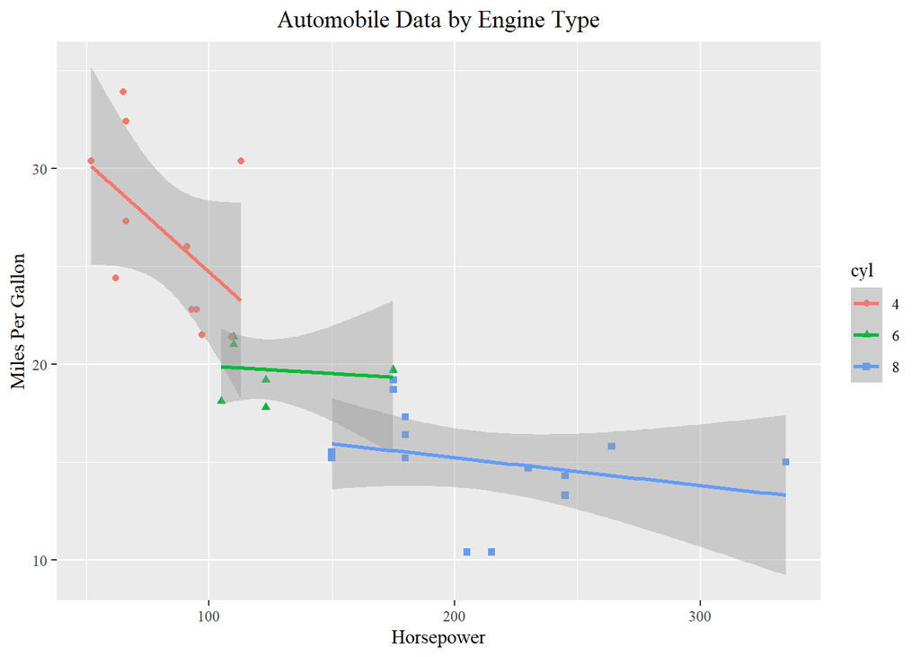

```r
mtcars1 %>%
  ggplot(aes(hp,mpg)) +
  geom_point(aes(shape = cyl,col = cyl)) +
  geom_smooth(aes(col = cyl),method = "lm") +
  labs(title="Automobile Data by Engine Type",
       x="Horsepower",
       y="Miles Per Gallon") +
  theme(text = element_text(family = enfont),
        plot.title = element_text(hjust = 0.5))
```

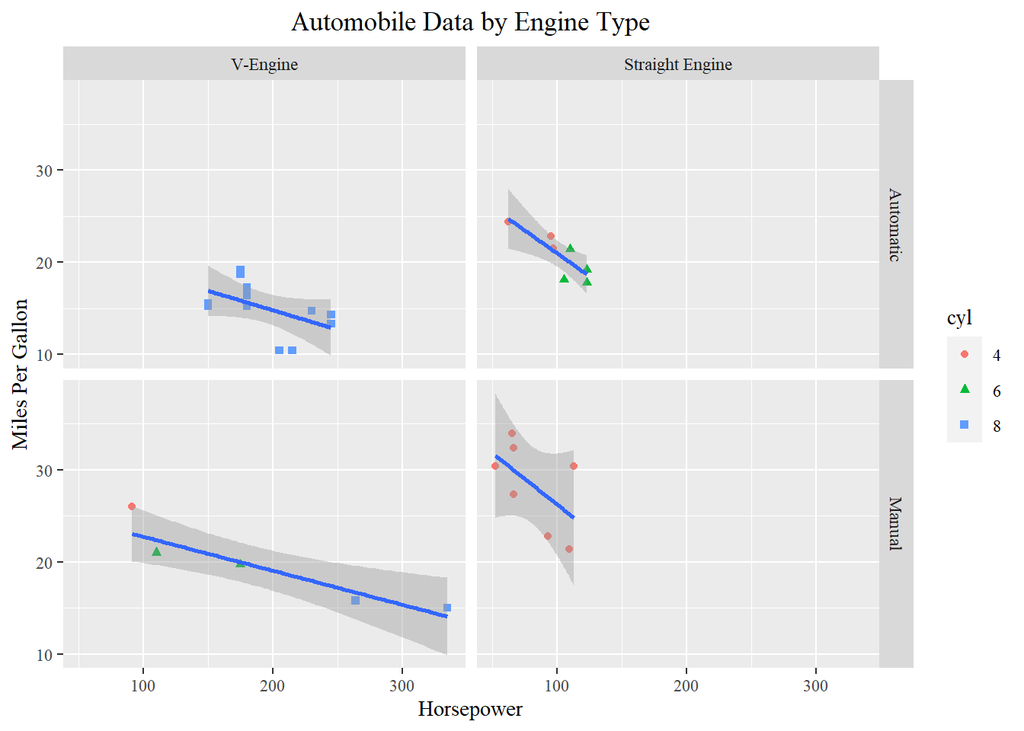

```r
mtcars1 %>%
  ggplot(aes(hp,mpg)) +
  geom_point(aes(shape = cyl,col = cyl)) +
  geom_smooth(method = "lm") +
  facet_grid(am~vs) +
  labs(title="Automobile Data by Engine Type",
       x="Horsepower",
       y="Miles Per Gallon") +
  theme(text = element_text(family = enfont),
        plot.title = element_text(hjust = 0.5))
```

# 4 用几何函数指定图的类型

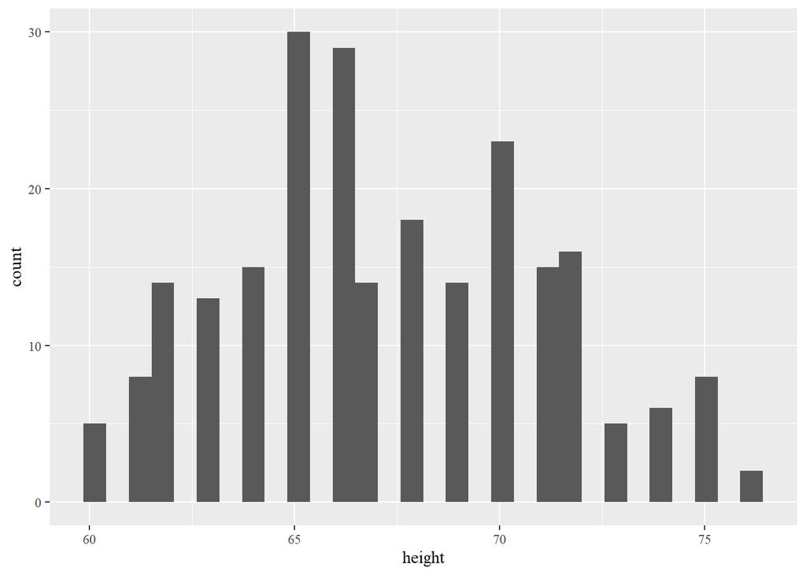

```r
data(singer,package = "lattice")
singer %>%
  ggplot() +
  geom_histogram(aes(x = height)) +
  theme(text = element_text(family = enfont),
        plot.title = element_text(hjust = 0.5))
```

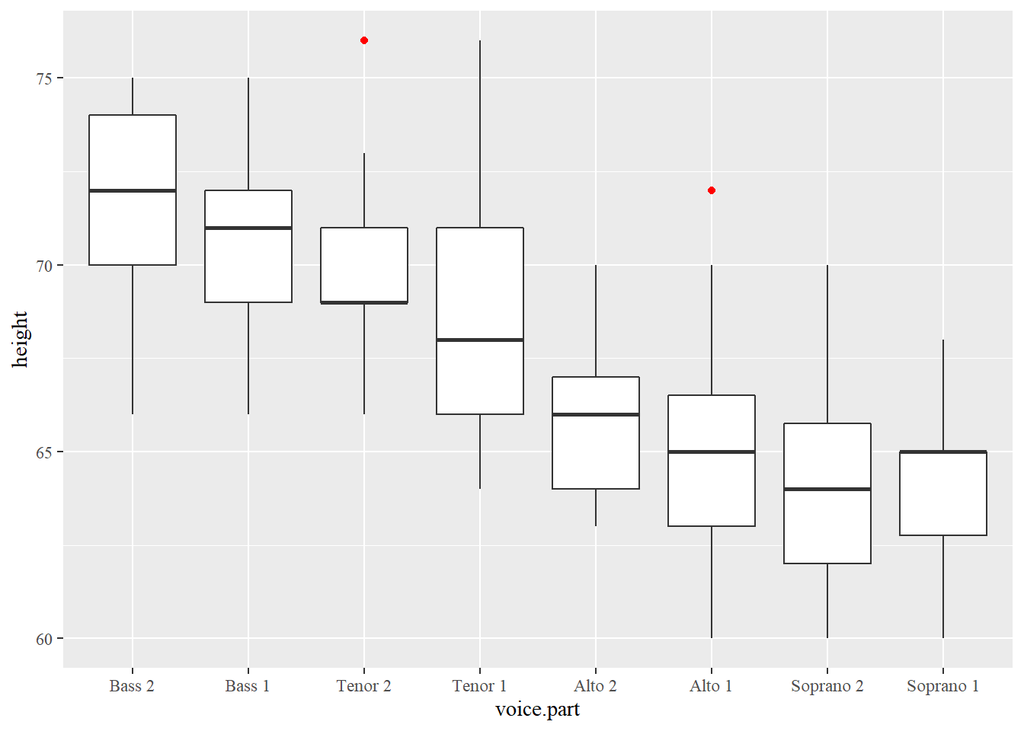

```r
ggplot(singer, aes(x=voice.part, y=height)) +
  geom_boxplot(outlier.colour = "red") +
  theme(text = element_text(family = enfont),
        plot.title = element_text(hjust = 0.5))
```

- **color** 对点、线和填充区域的边界进行着色
- **fill** 对填充区域着色，如条形和密度区域
- **alpha** 颜色的透明度，从0（完全透明）到1（不透明）。
- **linetype** 图案的线条（ 1=实线， 2=虚线， 3=点， 4=点破折号， 5=长破折号， 6=双破折号）
- **size** 点的尺寸和线的宽度
- **shape** 点的形状（和pch一样，0=开放的方形，1=开放的圆形，2=开放的三角形，等等）
- **position** 绘制诸如柱状图和点等对象的位置。对柱状图来说， “dodge”将分组条形图并排， “stacked”堆叠分组条形图， “fill”垂直地堆叠分组条形图并规范其高度相等。对于点来说， - “jitter”减少点重叠
- **binwidth** 直方图的宽度
- **notch** 表示方块图是否应为缺口（ TRUE/FALSE）
- **sides** 地毯图的安置（ “b”=底部，“l”=左部，“t”=顶部，“r”=右部，“bl”=左下部，等等）
- **width** 箱线图的宽度

我们可以使用Salaries数据集来验证这些选项的使用

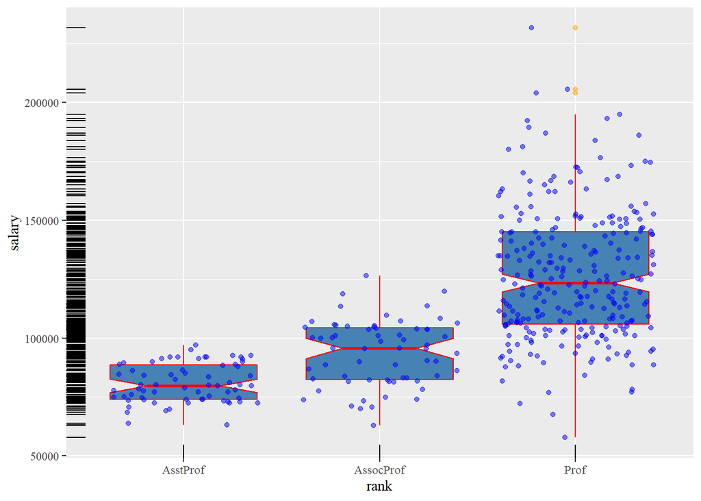

```r
Salaries %>%
  ggplot(aes(rank,salary)) +
  geom_boxplot(fill = "steelblue",color="red",notch=TRUE,outlier.color = "orange",
               outlier.alpha = 0.5) +
  geom_point(position="jitter", color="blue", alpha = 0.5) +
  geom_rug(side="l", color="black") +
  theme(text = element_text(family = enfont),
        plot.title = element_text(hjust = 0.5))
```

当几何函数组合形成新类型的图时，ggplot2包的真正力量就会得到展现。让我们回到singer数据集中

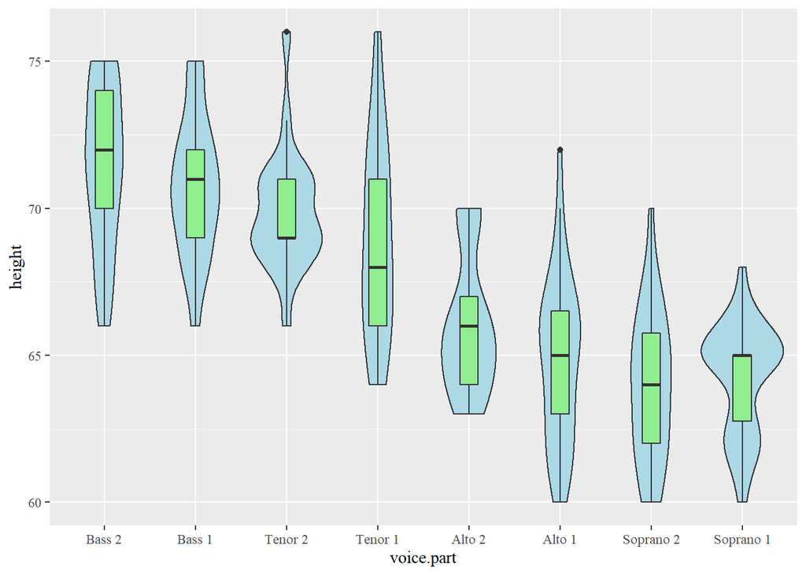

```r
data(singer, package = "lattice")
ggplot(singer, aes(x = voice.part, y = height)) +
  geom_violin(fill = "lightblue") +
  geom_boxplot(fill="lightgreen", width=.2) +
  theme(text = element_text(family = enfont),
        plot.title = element_text(hjust = 0.5))
```

该代码把**箱线图**和**小提琴图**结合在一起形成一个新的图形,箱线图展示了在singer数据框中每个音部的**25%、 50%和75%分位数得分**和任意的异常值。对于每个声部身高范围上的得分分布，小提琴图展示了更多视觉线索。

# 5 分组

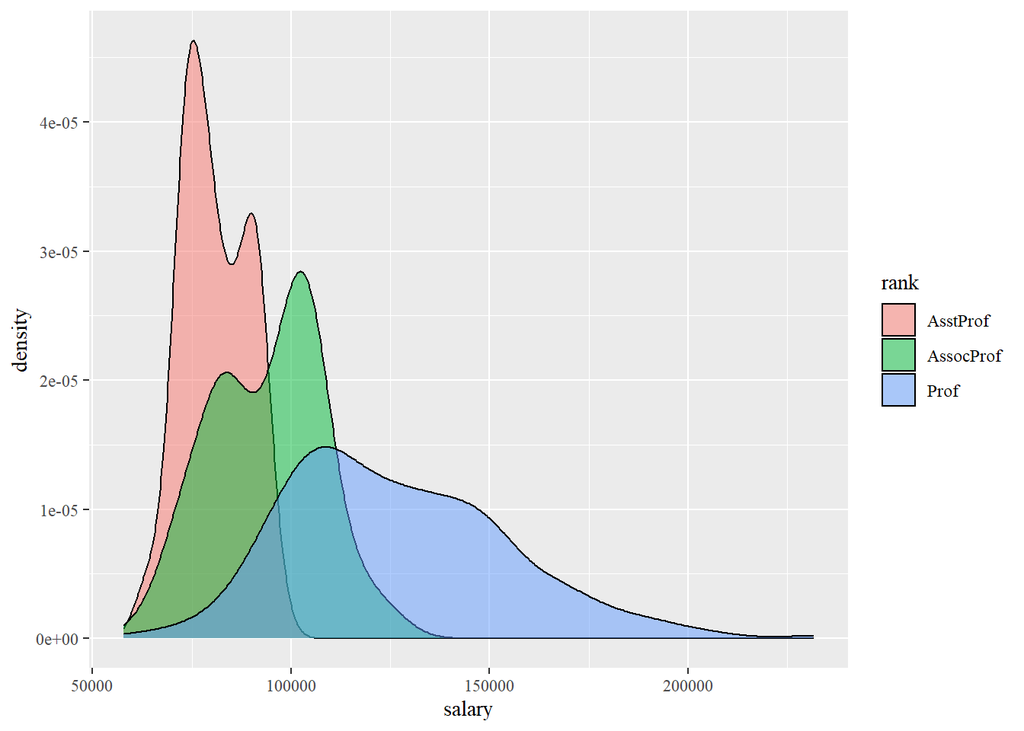

```r
library(ggplot2)
ggplot(data = Salaries, aes(x = salary, fill = rank)) +
  geom_density(alpha = 0.5) +
  theme(text = element_text(family = enfont),
        plot.title = element_text(hjust = 0.5))
```

接下来，我们通过性别和学术等级分组，绘制获得博士学位年数与薪水的关系

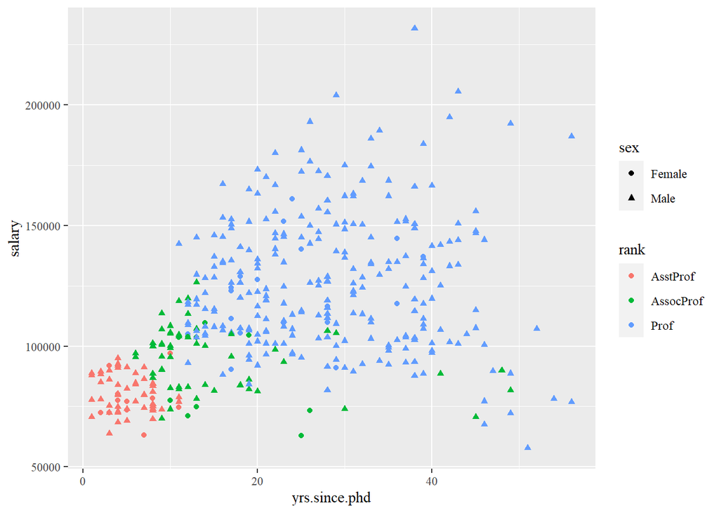

```r
Salaries %>%
  ggplot(aes(yrs.since.phd,salary,col = rank,shape = sex)) +
  geom_point() +
  theme(text = element_text(family = enfont),
        plot.title = element_text(hjust = 0.5))
```

用一个分组的条形图按学术等级和性别来可视化教授的人数

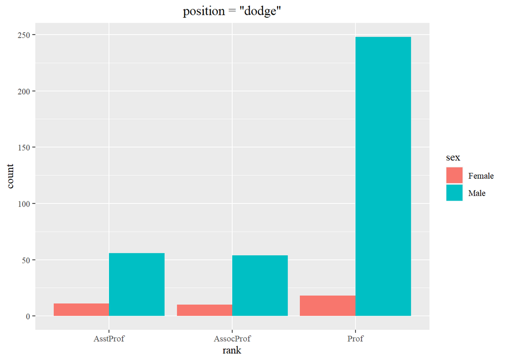

```r
Salaries %>%
  ggplot(aes(x = rank)) +
  geom_bar(aes(fill = sex),position = "dodge") +
  labs(title='position = "dodge"') +
  theme(text = element_text(family = enfont),
        plot.title = element_text(hjust = 0.5))
```

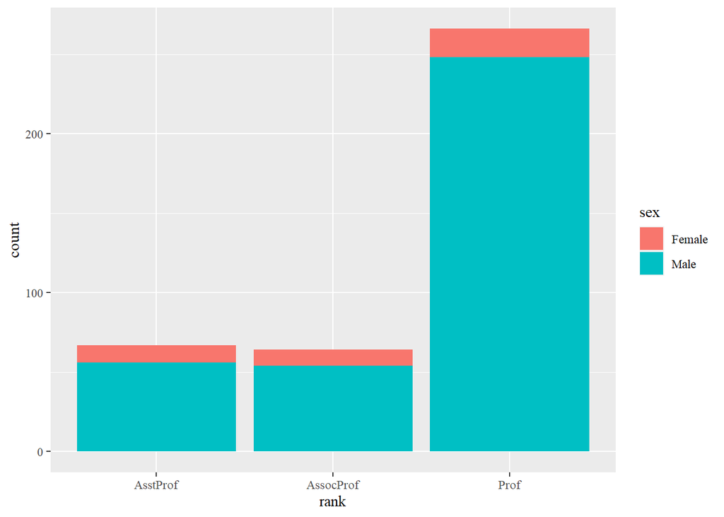

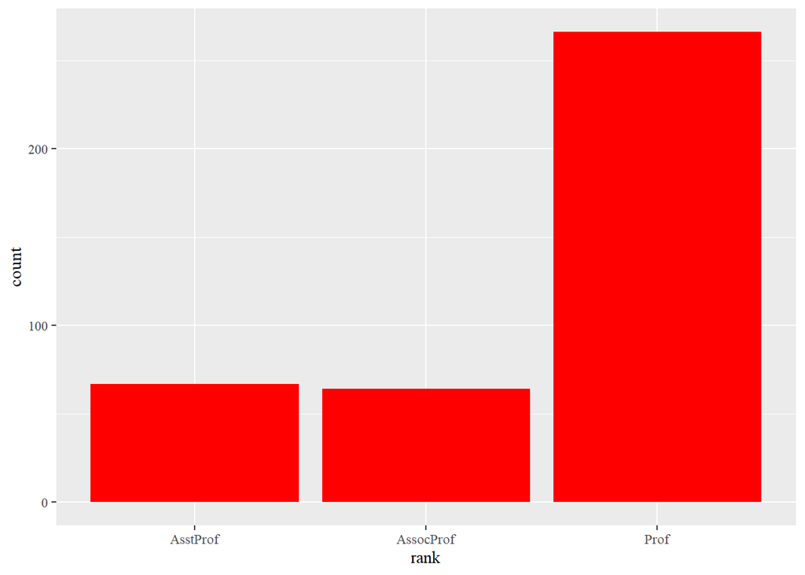

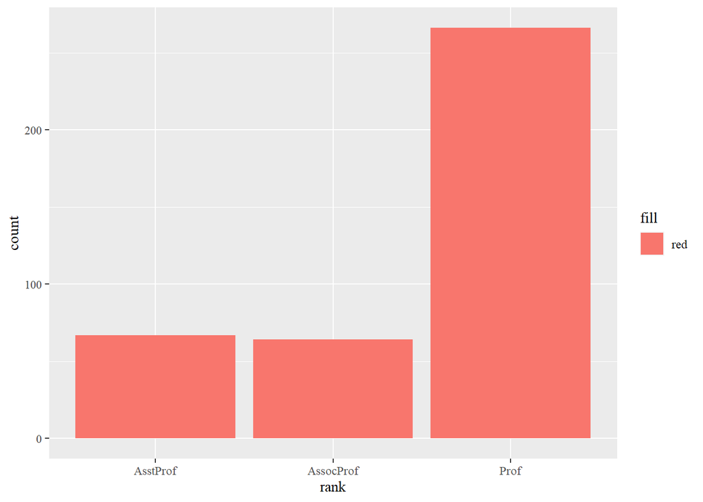

```r
ggplot(Salaries, aes(x=rank, fill=sex))+ geom_bar() +
  theme(text = element_text(family = enfont),
        plot.title = element_text(hjust = 0.5))

ggplot(Salaries, aes(x=rank)) + geom_bar(fill="red") +
  theme(text = element_text(family = enfont),
        plot.title = element_text(hjust = 0.5))

ggplot(Salaries, aes(x=rank, fill="red")) + geom_bar() +
  theme(text = element_text(family = enfont),
        plot.title = element_text(hjust = 0.5))
```

在第一个例子中，sex变量通过条形图中的fill来展示。在第二个例子中，每个条形图都用红色来填充。在第三个例子中， ggplot2假定“red”是变量的名字，并且你得到一个意想不到（不希望）的结果。通常来说，**变量应该设在aes()函数内，分配常数应该在aes()函数外**。

# 6 分面

回头看一下合唱的例子，我们可以使用下面的代码创建一个分面图

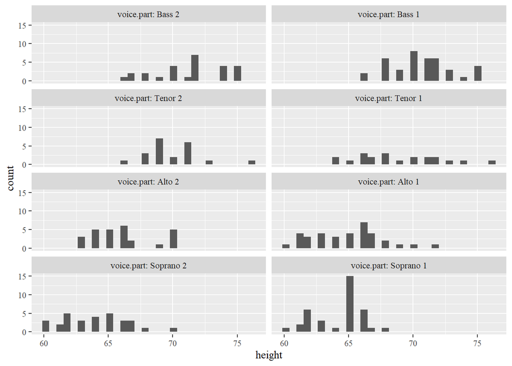

```r
singer %>%
  ggplot(aes(x = height)) +
  geom_histogram() +
  facet_wrap(~voice.part,nrow = 4,labeller = "label_both") +
  theme(text = element_text(family = enfont),
        plot.title = element_text(hjust = 0.5))
```

创建一个包含分面和分组的图

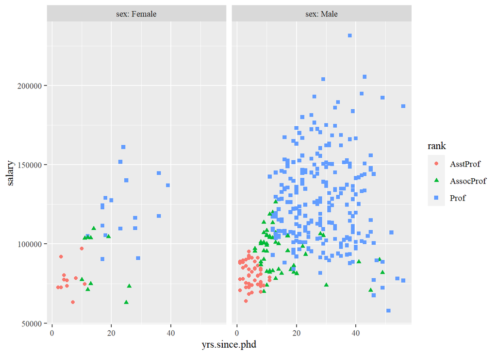

```r
Salaries %>%
  ggplot(aes(x = yrs.since.phd,y = salary,
             col = rank,shape = rank),size = 2.5) +
  geom_point() +
  facet_grid(.~sex,labeller = "label_both") +
  theme(text = element_text(family = enfont),
        plot.title = element_text(hjust = 0.5))
```

展示singer数据集中每个声部成员的身高分布，并利用核密度图水平排列。给每个声部分配不同的颜色。

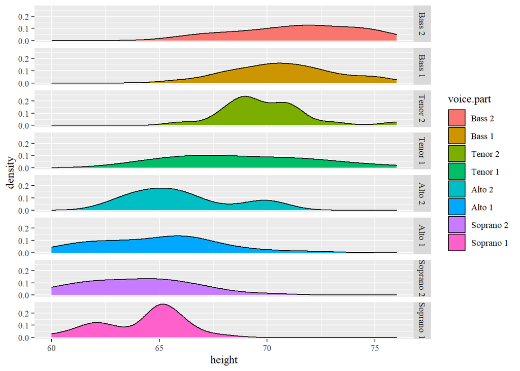

```r
singer %>%
  ggplot(aes(x = height,fill = voice.part)) +
  geom_density() +
  facet_grid(voice.part~.) +
  theme(text = element_text(family = enfont),
        plot.title = element_text(hjust = 0.5))
```

# 7 添加光滑曲线

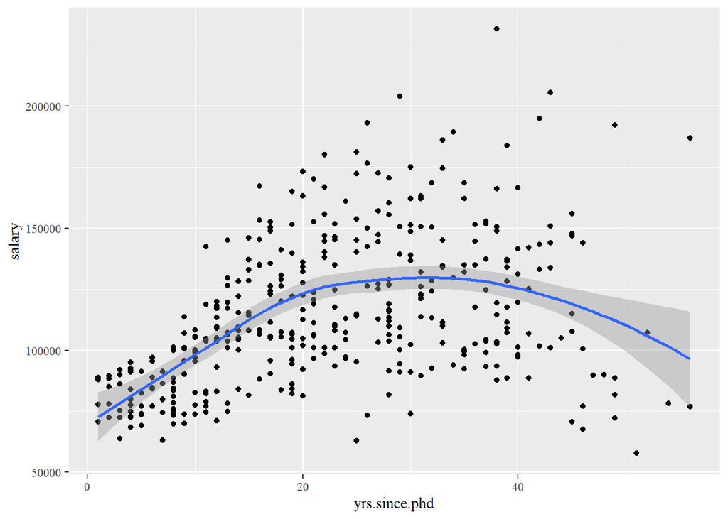

```r
Salaries %>%
  ggplot(aes(x = yrs.since.phd,y = salary)) +
  geom_point() +
  geom_smooth() +
  theme(text = element_text(family = enfont),
        plot.title = element_text(hjust = 0.5))
```

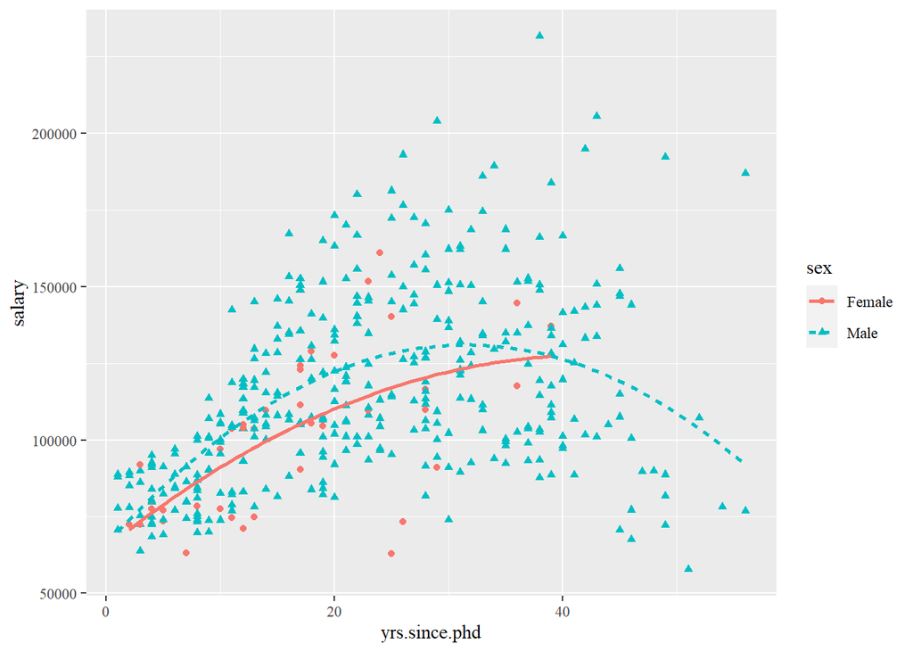

```r
Salaries %>%
  ggplot(aes(x = yrs.since.phd,y = salary)) +
  geom_point(aes(col = sex,shape = sex)) +
  geom_smooth(aes(linetype = sex,col = sex),method=lm, formula=y~poly(x,2),
              se = FALSE) +
  theme(text = element_text(family = enfont),
        plot.title = element_text(hjust = 0.5))
```

对男性来说，曲线从0增加至约30年然后下降。对女性来说，拟合曲线从0到40年一直呈上升 趋势。在数据集中没有女性获得博士学位超过40年。对于数据集中的大部分范围，男性能拿到更高的薪水。

# 8 修改ggplot2图形的外观

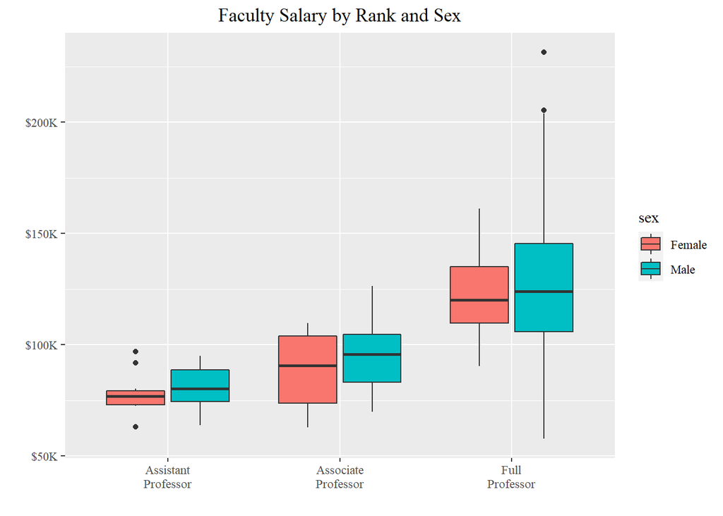

```r
Salaries %>%
  ggplot(aes(x = rank, y = salary, fill = sex)) +
  geom_boxplot() +
  scale_y_continuous(breaks = seq(50000, 200000, 50000),
                     labels = str_c("$", seq(50, 200, 50), "K")) +
  scale_x_discrete(
    breaks = c("AsstProf", "AssocProf", "Prof"),
    labels = c(
      "Assistant\nProfessor",
      "Associate\nProfessor",
      "Full\nProfessor"
    )
  ) +
  labs(title="Faculty Salary by Rank and Sex", x="", y="") +
  theme(text = element_text(family = enfont),
        plot.title = element_text(hjust = 0.5))
```

很明显，平均收入随着学术排名的上升而上升，在每个学术等级中男性的薪资水平高于女性。

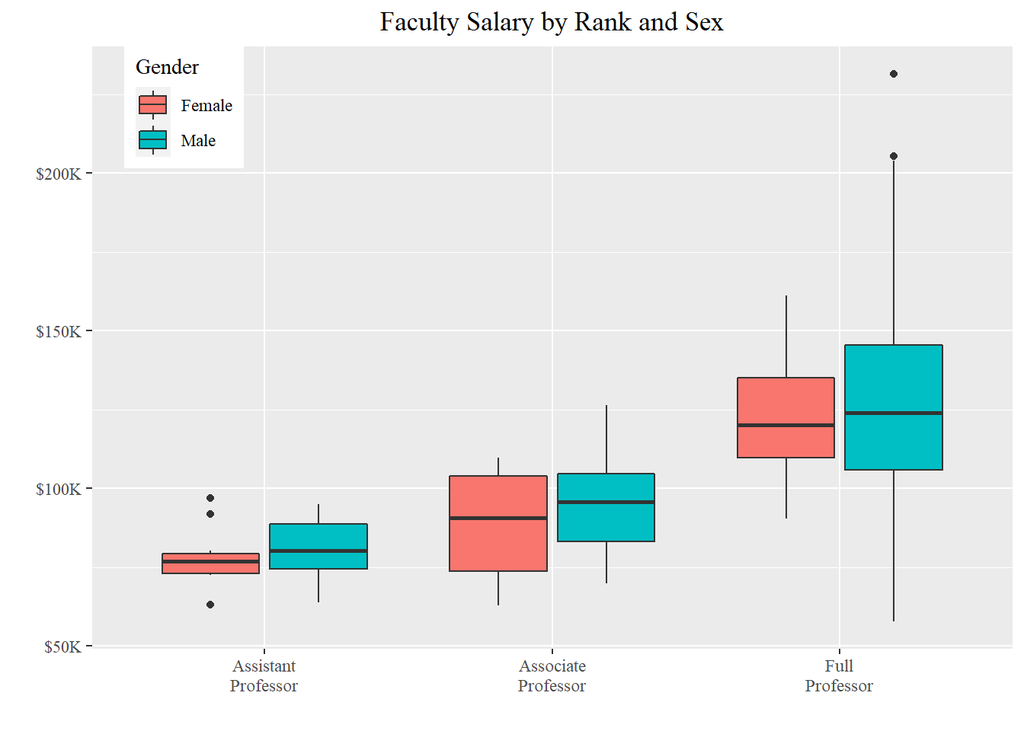

```r
Salaries %>%
  ggplot(aes(x = rank, y = salary, fill = sex)) +
  geom_boxplot() +
  scale_y_continuous(breaks = seq(50000, 200000, 50000),
                     labels = str_c("$", seq(50, 200, 50), "K")) +
  scale_x_discrete(
    breaks = c("AsstProf", "AssocProf", "Prof"),
    labels = c(
      "Assistant\nProfessor",
      "Associate\nProfessor",
      "Full\nProfessor"
    )
  ) +
  labs(title="Faculty Salary by Rank and Sex", x="", y="",
       fill = "Gender") +
  theme(text = element_text(family = enfont),
        plot.title = element_text(hjust = 0.5)) +
  theme(legend.position = c(.1,.9))
```

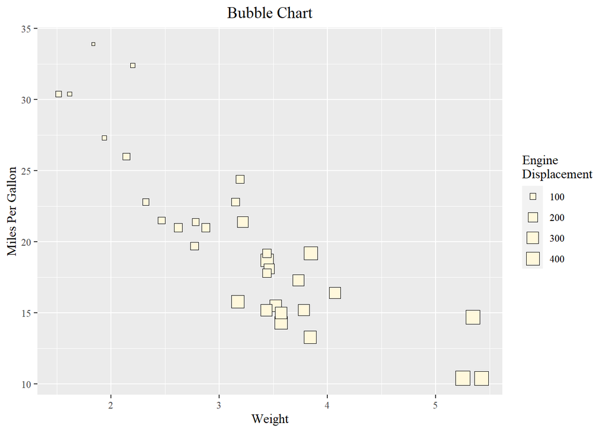

```r
ggplot(mtcars, aes(x = wt, y = mpg, size = disp)) +
  geom_point(shape = 22,
             color = "black",
             fill = "cornsilk") +
  labs(x = "Weight",
       y = "Miles Per Gallon",
       title = "Bubble Chart",
       size = "Engine\nDisplacement") +
  theme(text = element_text(family = enfont),
        plot.title = element_text(hjust = 0.5))
```

使用`scale_color_manual()函数`来设定三个学术等级的点的颜色

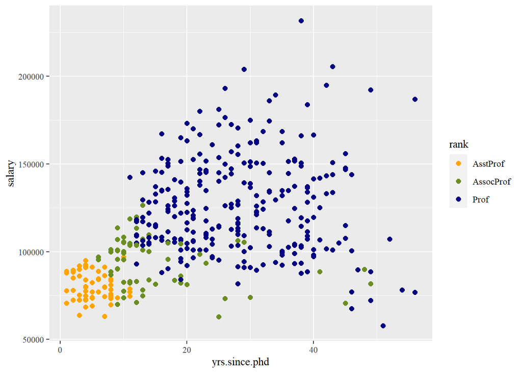

```r
ggplot(data = Salaries, aes(x = yrs.since.phd, y = salary, color = rank)) +
  scale_color_manual(values = c("orange", "olivedrab", "navy")) +
  geom_point(size = 2) +
  theme(text = element_text(family = enfont),
        plot.title = element_text(hjust = 0.5))
```

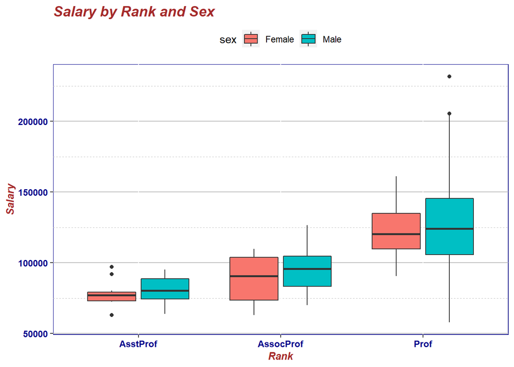

```r
library(ggplot2)
mytheme <- theme(
  plot.title = element_text(face = "bold.italic",
                            size = "14",
                            color = "brown"),
  axis.title = element_text(face = "bold.italic",
                            size = 10,
                            color = "brown"),
  axis.text = element_text(face = "bold",
                           size = 9,
                           color = "darkblue"),
  panel.background = element_rect(fill = "white",
                                  color = "darkblue"),
  panel.grid.major.y = element_line(color = "grey",
                                    linetype = 1),
  panel.grid.minor.y = element_line(color = "grey",
                                    linetype = 2),
  panel.grid.minor.x = element_blank(),
  legend.position = "top"
)
ggplot(Salaries, aes(x = rank, y = salary, fill = sex)) +
  geom_boxplot() +
  labs(title = "Salary by Rank and Sex", x = "Rank", y = "Salary") +
  mytheme
```

主题mytheme指定了**图的标题**应该为粗斜体的棕色14号字。**轴的标题**为粗斜体的棕色10号字。**坐标轴标签**应为加粗的深蓝色9号字。**画图区域**有白色的填充和深蓝色的边框。**主水平网格**应该是灰色的实线，**次水平网格**应该是灰色的虚线；**垂直网格**不输出；**图例**展示在图的顶部。`theme()函数`给了我们把控最后图形的控制权。可以参考help(theme)来查看更多关于选项的信息。

# 9 组合图形

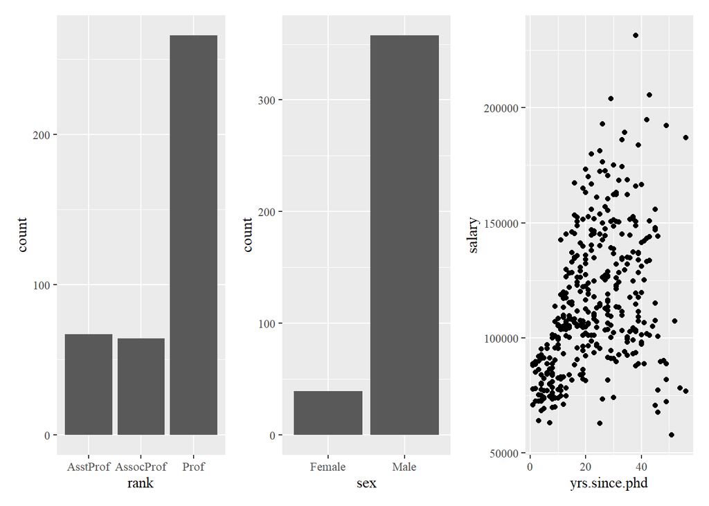

```r
library(patchwork)
p1 <- ggplot(data=Salaries,
             aes(x=rank)) +
  geom_bar() +
  theme(text = element_text(family = enfont),
        plot.title = element_text(hjust = 0.5))

p2 <- ggplot(data=Salaries,
             aes(x=sex)) + geom_bar() +
  theme(text = element_text(family = enfont),
        plot.title = element_text(hjust = 0.5))

p3 <- ggplot(data=Salaries,
             aes(x=yrs.since.phd, y=salary)) + geom_point() +
  theme(text = element_text(family = enfont),
        plot.title = element_text(hjust = 0.5))

p1 + p2 + p3
```

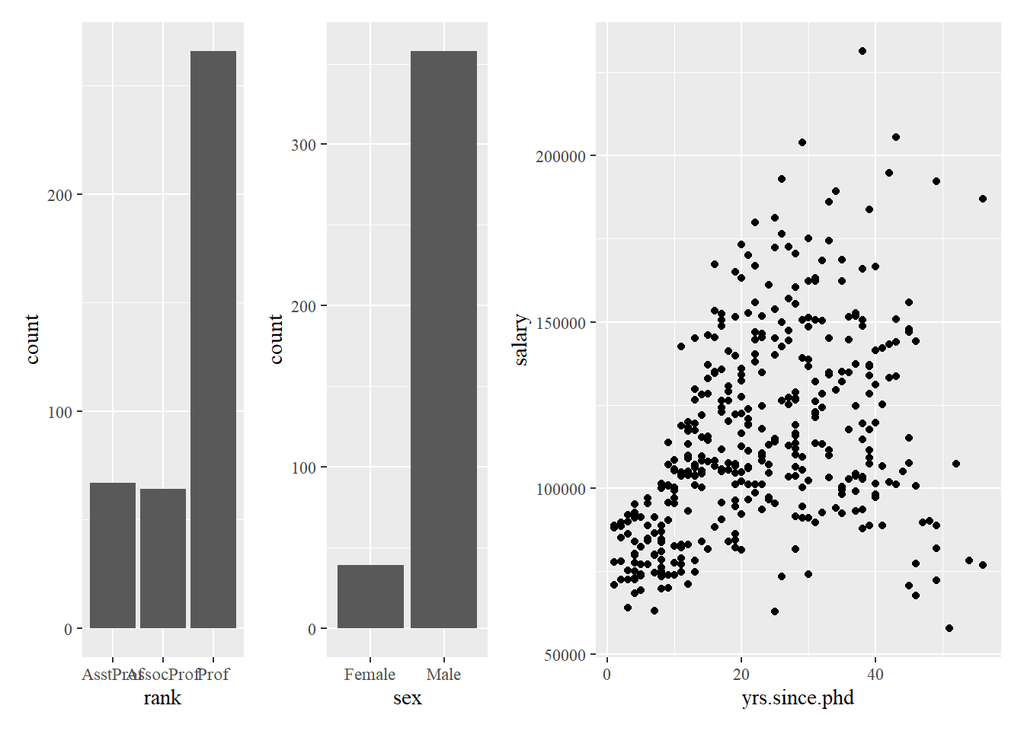

```r
p1 + p2 - p3
```

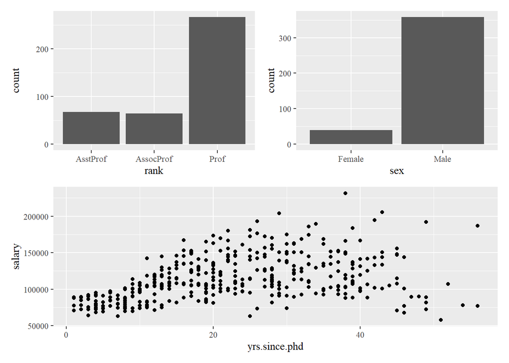

```r
(p1 + p2)/p3
```

# 10 保存图形

```r
myplot <- ggplot(data=mtcars, aes(x=mpg)) + geom_histogram()
# ggsave(file="mygraph.png", plot=myplot, width=5, height=4)
```

在当前路径下将myplot保存为名为mygraph.png的**5英寸×4英寸**（12.7厘米×10.2厘米） PNG格式的图片。我们可以通过设定文件扩展名为ps、tex、jpeg、pdf、tiff、png、bmp、svg或wmf来保存为不同的格式。wmf文件仅限在装有Windows系统的计算机中保存。如果忽略`plot=`选项，最近创建的图形会被保存。

# 11 小结

本章回顾了ggplot2包，它提供基于**图形综合语法**的先进图形化方法。这个包旨在在R提供 的基础画图之外提供一个完整而全面的替代方案。它提供的数据可视化方法很有吸引力和意义，用其他方式很难做到。